# Lab 5 Report

Ollie Murphy

10/6/2021

##### 1. Show the R code you used to create exp_fun()

```r
exp_fun = function(x, a, b)
{
  return(a * exp(-b * x))
}
```

##### 2. In your lab report, include a single figure containing four negative exponential curves.

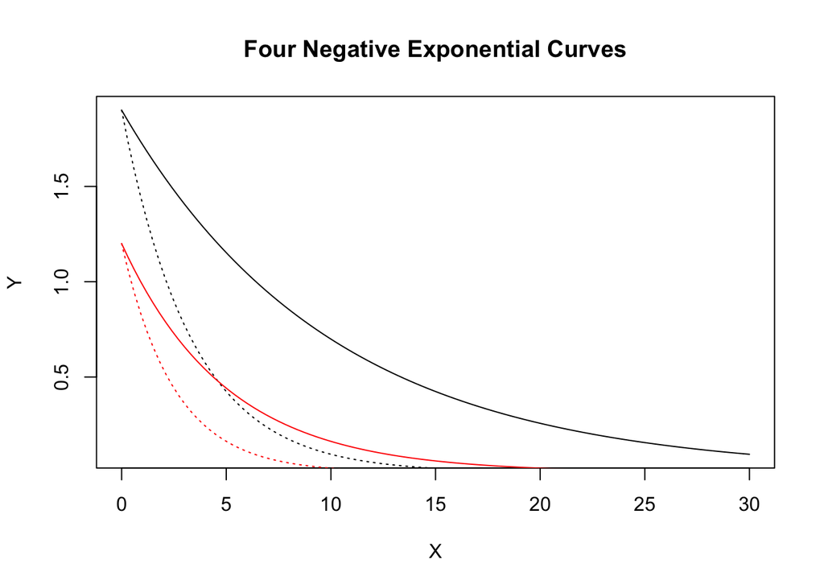

```r
curve(
  exp_fun(x, 1.9, .1), from = 0, to = 30, col = "black", lty = "solid", xlab = "X", ylab = "Y", main = "Four Negative Exponential Curves")

curve(
  exp_fun(x, 1.9, .3), col = "black", lty = "dotted", add = TRUE)

curve(
  exp_fun(x, 1.2, .2), col = "red", lty = "solid", add = TRUE)

curve(
  exp_fun(x, 1.2, .4), col = "red", lty = "dotted", add = TRUE)
```

#### Observe how the curves vary as you change the two parameters’ values.

##### 3. Qualitatively describe what happens to the curve as you vary parameter a.

- As parameter a varies, the y value at x = 0 changes; when a is larger, the exponential curve starts higher up the y axis, and when a is smaller, the curve starts lower on the y axis.

##### 4. Qualitatively describe what happens to the curve as you vary parameter b.

- As parameter b increases, the y value decreases more rapidly as x increases. In other words, the higher the b value, the steeper the slope of the derivative of the curve.

##### 5. In your lab report, include a single plot containing 6 Ricker curves

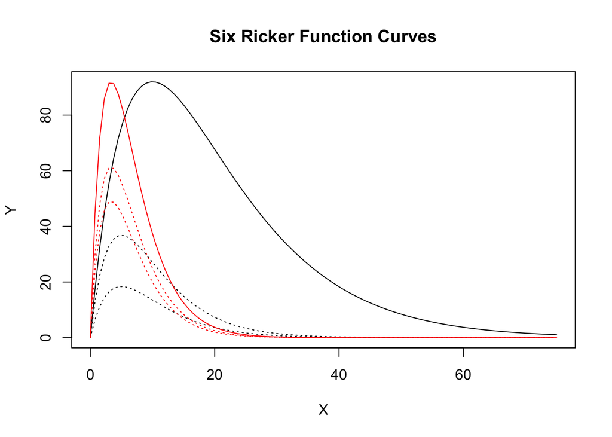

```r
ricker_fun = function(x, a, b)
{
  return(a * x * exp(-b * x))
}

curve(ricker_fun(x, 25, .1), col = "black", lty = "solid", from = 0, to = 75, xlab = "X", ylab = "Y", main = "Six Ricker Function Curves")
curve(
  ricker_fun(x, 20, .2),
  col = "black", lty = "dotted", add = TRUE)
curve(
  ricker_fun(x, 10, .2),
  col = "black", lty = "dotted", add = TRUE)
curve(
  ricker_fun(x, 75, .3),
  col = "red", lty = "solid", add = TRUE)
curve(
  ricker_fun(x, 50, .3),
  col = "red", lty = "dotted", add = TRUE)
curve(
  ricker_fun(x, 40, .3),
  col = "red", lty = "dotted", add = TRUE)
```

### Observe how the curves vary as you change the two parameters’ values.

##### 6. Qualitatively describe what happens to the curve as you vary parameter a.

- As parameter a increases, so does the slope of the curve as x approaches 1/b. Visually, this means that the peak is higher and the slope of the first line section is steeper as a increases.

##### 7. Qualitatively describe what happens to the curve as you vary parameter b.

- As parameter b increases, the x value with the largest y value decreases. Visually, this means that the peak of the curve moves closer to the y axis as b increases.

```r
#install.packages("here")
require(here)
sal_dist = read.csv(here("Labs", "Lab_5", "salamander_dispersal.csv"))

#line_point_slope funtion
line_point_slope = function(x, x1, y1, slope)
{
  get_y_intercept =
    function(x1, y1, slope)
      return(-(x1 * slope) + y1)

  linear =
    function(x, yint, slope)
      return(yint + x * slope)

  return(linear(x, get_y_intercept(x1, y1, slope), slope))
}
```

##### 8. Linear Model. Provide the values of the slope and intercept parameters you chose. Briefly describe how you chose the values.

- I used a point from the center of the plot to visually fit my linear model– (500, .4). I then chose a very small negative slope to reflect the very slow downward trend on the data.

##### 9. Include a scatterplot of the salamander data with your fitted linear model.

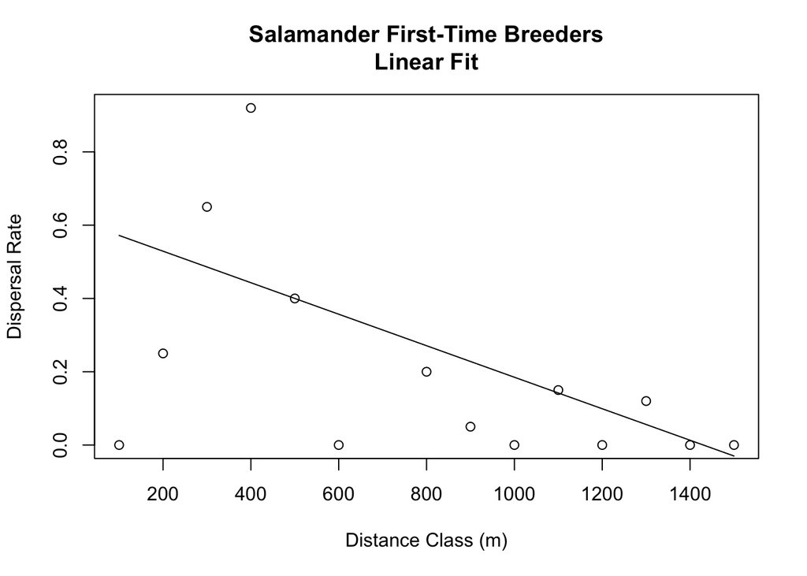

```r
guess_x = 500
guess_y = 0.4
guess_slope = -.00043

plot(sal_dist$dist.class, sal_dist$disp.rate.ftb, main = "Salamander First-Time Breeders\nLinear Fit", xlab = "Distance Class (m)", ylab = "Dispersal Rate")
curve(line_point_slope(x, guess_x, guess_y, guess_slope), add = TRUE)
```

##### 10. Exponential Model. Provide the values of the a and b. Briefly describe how you chose the values.

- I chose a = 1 and b = .0035. I chose a because I know that it is equal to the y value when x = 0, and that is about the upper limit of the y values.I originally used .8, but found that using 1 fit the data more closely. Finding b was a process of trial and error–I thought that it might be low, because it is related to slope and the slope of the linear fit was very small. I knew it would be a positive number because the function itself defines b as a negative number. From there, a few guesses helped me to hone in on .0035 as the b value.

##### 11. Include a scatterplot of the salamander data with your fitted exponential model.

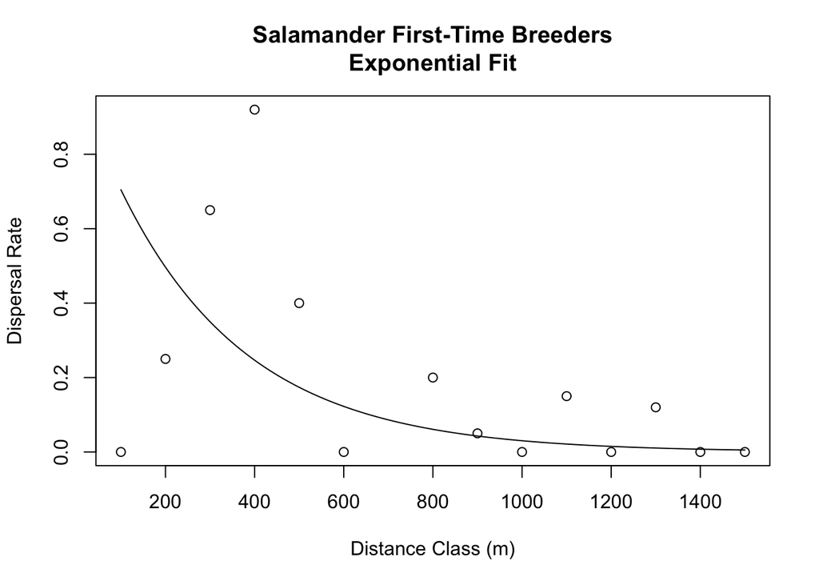

```r
plot(sal_dist$dist.class, sal_dist$disp.rate.ftb, main = "Salamander First-Time Breeders\nExponential Fit", xlab = "Distance Class (m)", ylab = "Dispersal Rate")
curve(exp_fun(
  x, 1, .0035), add = TRUE)
```

##### 13.

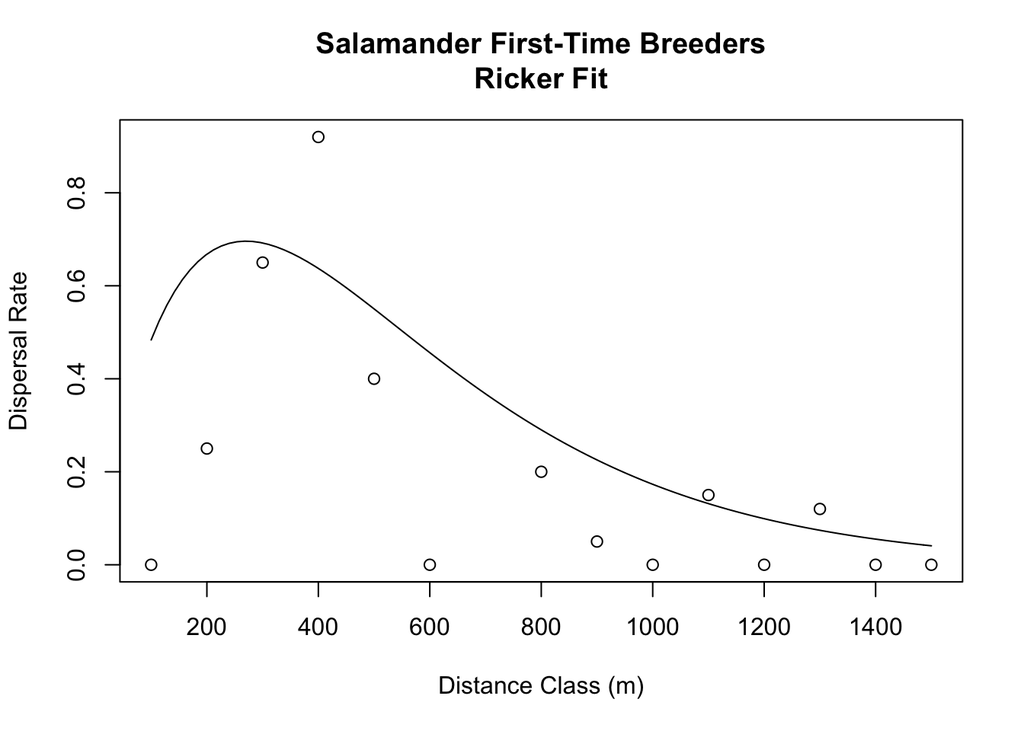

```r
plot(sal_dist$dist.class, sal_dist$disp.rate.ftb, main = "Salamander First-Time Breeders\nRicker Fit", xlab = "Distance Class (m)", ylab = "Dispersal Rate")
curve(ricker_fun(
  x, .007, .0037), add = TRUE)
```

##### 14. Show the R code you used to create your data frame of model residuals.

```r
sal_dist$linear = line_point_slope(sal_dist$dist.class, guess_x, guess_y, guess_slope)
sal_dist$exp = exp_fun(sal_dist$dist.class, 1, .0035)
sal_dist$ricker = ricker_fun(sal_dist$dist.class, .007, .0037)

sal_dist$resids_linear = sal_dist$disp.rate.ftb - sal_dist$linear
sal_dist$resids_exp = sal_dist$disp.rate.ftb - sal_dist$exp
sal_dist$resids_ricker = sal_dist$disp.rate.ftb - sal_dist$ricker
```

##### 15. Include histograms of the residuals for each of your three models.

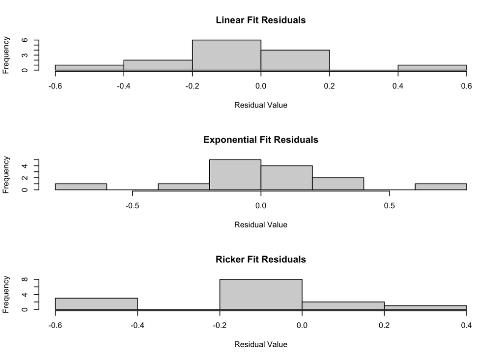

```r
par(mfrow = c(3, 1))
hist(sal_dist$resids_linear, main = "Linear Fit Residuals", xlab = "Residual Value")
hist(sal_dist$resids_exp, main = "Exponential Fit Residuals", xlab = "Residual Value")
hist(sal_dist$resids_ricker, main = "Ricker Fit Residuals", xlab = "Residual Value")
```